# 2016 Alzheimer Disease Mortality in the USA

Raveendra Swarna

8/19/2018

In this post, I will make a map of the prevalence of Alzheimer disease mortality by the state in the USA. The Centers for Disease Control and Prevention is providing the data for download, and they have created a beautiful map. I will try to reproduce the same results using several packages in R.

```r
dt_ad <- read.csv("~/Documents/gitrepos/alzhiemers2016/data/ALZHEIMERS2016.csv")
head(dt_ad)
```

```
##   STATE RATE DEATHS                                              URL
## 1    AL 45.0  2,507       /nchs/pressroom/states/alabama/alabama.htm
## 2    AK 25.8    111         /nchs/pressroom/states/alaska/alaska.htm
## 3    AZ 35.8  3,082       /nchs/pressroom/states/arizona/arizona.htm
## 4    AR 41.3  1,475     /nchs/pressroom/states/arkansas/arkansas.htm
## 5    CA 36.1 15,570 /nchs/pressroom/states/california/california.htm
## 6    CO 34.7  1,835     /nchs/pressroom/states/colorado/colorado.htm
```

[output not shown]

Now, I have two datasets, one has the rate of mortality from Alzheimer disease and the other have variables with the information to create maps. I need to merge both datasets together but I dont have a similar variable for merge. Therefore, I will create a new region variable form the URL variable in the first dataset and will use to merge with the second dataset. For this purpose, I will use the function separate and gsub. In the end I will merge with states dataset by region.

```r
#get the state name from URL
dt_ad2 = dt_ad %>%
  separate(URL, c("a","b","c","d", "region"), sep="/") %>%
  select(RATE, region)
# removing white space for mergin purposes
dt_states2 = dt_states %>%
  mutate(region = gsub(" ","", region))
# merge
dt_final = left_join(dt_ad2, dt_states2)
```

# Visualization

The dt_final dataset have all the variables I need to make the map.

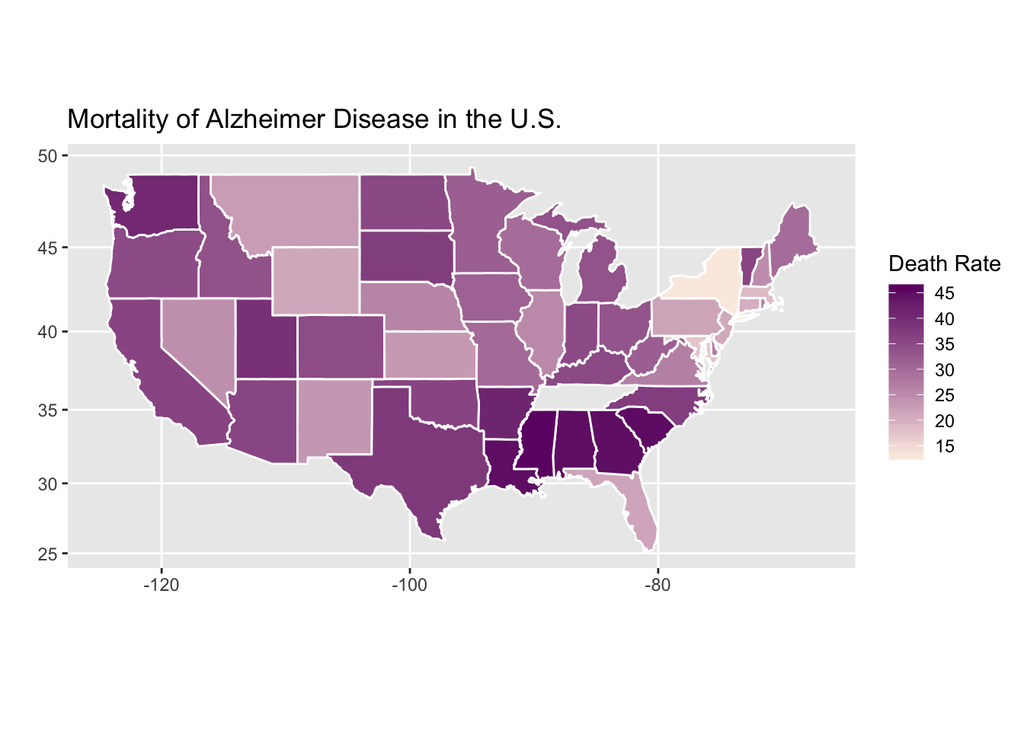

```r
ggplot(dt_final, aes(x = long, y = lat, group = group, fill = RATE)) +
  geom_polygon(color = "white") +
  scale_fill_gradient(
    name = "Death Rate",
    low = "#fbece3",
    high = "#6f1873",
    guide = "colorbar",
    na.value="#eeeeee",
    breaks = pretty_breaks(n = 5)) +
  labs(title="Mortality of Alzheimer Disease in the U.S.", x="", y="") +
  coord_map()
```

In this short post I showed how simple is to visualize the data in a map. I hope you like it and feel free to post a comment below or send me a message.